# Node support values and update of treestructure object with new sequences

Vinicius Franceschi

2025-05-14

# Introduction

In this tutorial, we will consider node support values (e.g. bootstrap) on cluster designations and update previous `treestructure` object with new sequences.

This tutorial uses SARS-CoV-2 public data available [here](https://hgdownload.soe.ucsc.edu/goldenPath/wuhCor1/UShER_SARS-CoV-2//2022/04/02/) to demonstrate the use of node support values from e.g. parametric bootstrap to avoid designating population structure in badly supported clades. This tutorial also demonstrates how to update previous cluster designations (an existing `treestructure` object) using a new rooted maximum likelihood tree incorporating more sequences. The new tips are added to the cluster which shares its MRCA (most recent common ancestor).

# Workflow to analyse SARS-CoV-2 sequence data

For a step-by-step guide to replicate the complete workflow please see [here](https://github.com/vinibfranc/demo_treestructure/blob/main/R/prepare.R).

Briefly, we downloaded SARS-CoV-2 public metadata, a treefile, and multiple sequence alignments from the UShER index. Then we extracted sequences up to the end of February 2020 (n < 1,000 sequences). We then estimated a maximum likelihood (ML) tree with [IQ-TREE](http://www.iqtree.org/) v2.2.2.6 with 1,000 ultrafast bootstraps, a time-scaled tree using [`treedater`](https://github.com/emvolz/treedater) (strict clock and 0.0008 subst./site/year), removed outliers by root-to-tip regression, an then re-estimated the timetree without the outliers (n = 916).

Let’s load the resulting ML tree with bootstrap values:

```r
library(treestructure)
```

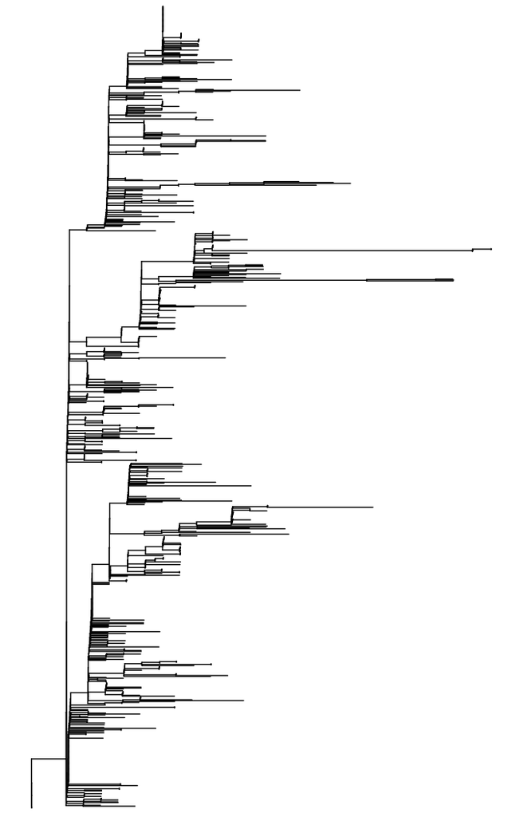

```r
mltr2_outl_rm <- readRDS( system.file('mltr2_outl_rm_sc2_feb2020.rds',
                                      package='treestructure') )

ggtree::ggtree(mltr2_outl_rm)
```

And here you can load the timetree:

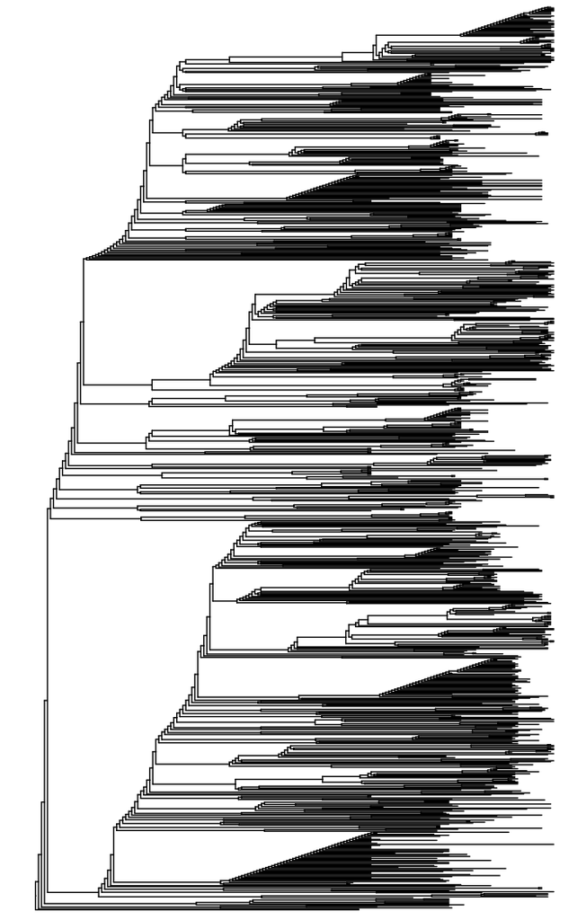

```r
timetr2_phylo <- readRDS( system.file('timetr2_phylo_sc2_feb2020.rds',
                                      package='treestructure') )

ggtree::ggtree(timetr2_phylo)
```

## Assign clusters without using node support

Firstly, we will assign clusters without using bootstrap support:

```r
trestruct_res_nobt <- trestruct(timetr2_phylo,
                                minCladeSize = 30,
                                nodeSupportValues = FALSE,
                                level = 0.01)
```

Because running `treestructure` will take several minutes to run, we can load the results:

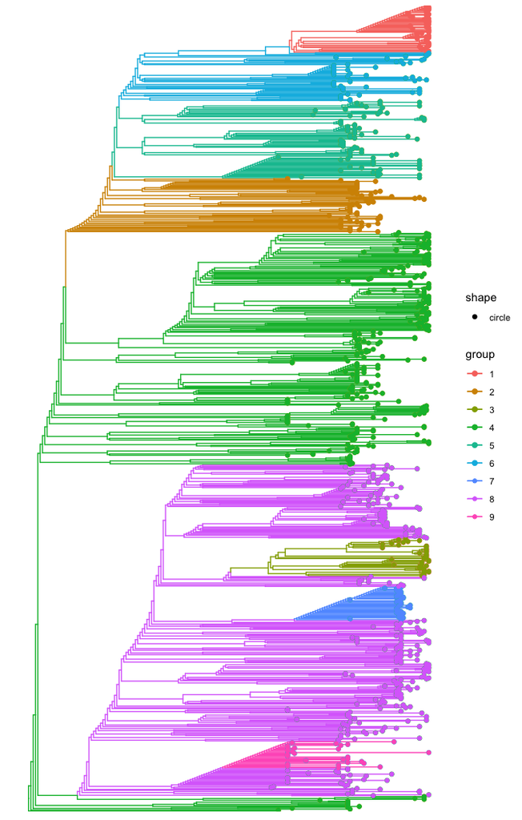

```r
trestruct_res_nobt <- readRDS( system.file('trestruct_res_nobt.rds',
                                           package='treestructure') )

plot(trestruct_res_nobt, use_ggtree = T) + ggtree::geom_tippoint()
```

The `treestructure` analyses resulted in 9 clusters.

## Assign clusters using bootstrap support

Let’s add the support values to a vector that we will pass to `trestruct`:

```r
timetr2_boot <- as.integer(mltr2_outl_rm$node.label)
timetr2_boot[is.na(timetr2_boot)] <- 95
print(timetr2_boot)
```

```
#>   [1]  95 100  12   3   6   2   6   7   1   6   5   7   6   6   7  11  50  99
#>  [19]   8   7   8 100   9   9   9  10   8   8   9   5   8   8  35  89   5   6
#>  [37]  10   9   8  10   5  24 100 100  75  26 100  67  74  95 100  95   5   2
#>  [55]  15 100 100  91  91   8 100  92   2  89  98  17   9  18   8 100 100 100
#>  [73]  71 100 100 100  19   7   7   8  19 100  83 100  83  84  20   9  16  20
#>  [91] 100   9  23  18  95  13  22  24 100  93  96  16   6   8   8  23   9   7
#> [109]   9   5   3   4  19  17 100  84  82  95  95   5 100  13   6  99  47  16
#> [127]  95   7  11  12  23  95  95  95  95 100  12   8  95  95   7  10  66 100
#> [145]  95  95  59  44   8  24  47  37  10   8   7   7  10   7   6   7   6   7
#> [163]   5   5   6   1   7   5   3  14 100 100   5   5   9  16 100  94 100  37
#> [181]  23  95  95  95  95  95  95  95  95  11  18  20 100  24  11  99 100  93
#> [199]  95  95  95  99   6   5   3   9  73  19   7   6   4  21 100   6   2  95
#> [217]  95  95  95  95  95  95  95  95  95  95  95   8  11  99 100  96   7  10
#> [235]  95  95  26   9   8   8   4  10 100  96  95  95  95  95  19 100  79  61
#> [253] 100   8  25 100   3  13 100  95  95  95  95  95  95  95  95  95  95  95
```

[output cut: 35 more lines]

Note that in the above example, some branches did not show a branch support as the tree was estimated with IQ-TREE and the alignment contained many identical tips. In our example we will assign to all these branches without a branch support, a node support of 95. However, in your own example, if too many identical sequences are present and if you want to estimate the branch support for all branches when estimating a tree with IQ-TREE, you should use the flag `-keep-ident`. See [here](https://github.com/iqtree/iqtree2/issues/343) for further details.

And, finally, we designate clusters that have at least 80% bootstrap support:

```r
trestruct_res <- trestruct(timetr2_phylo,
                           minCladeSize = 30,
                           nodeSupportValues = timetr2_boot,
                           nodeSupportThreshold = 80,
                           level = 0.01)
```

Because it will take a minute to run `treestructure`, we can load the result instead.

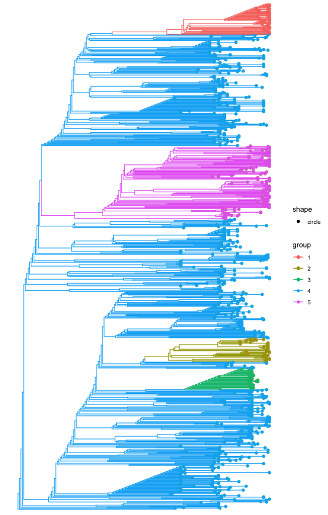

```r
trestruct_res <- readRDS( system.file('trestruct_res.rds',
                                      package='treestructure') )

plot(trestruct_res, use_ggtree = T) + ggtree::geom_tippoint()
```

Now we have only 5 well-supported clusters with differences in coalescent patterns.

## Update a previous treestrucuture object with new sequences

To update the previous `treestructure` object with new sequences, we extracted SARS-CoV-2 sequences up to 15 March 2020 (n > 6,500 sequences). We then estimated a new ML tree including all those sequences as before.

Note that this new tree must be rooted, but does not need to be time-scaled or binary.

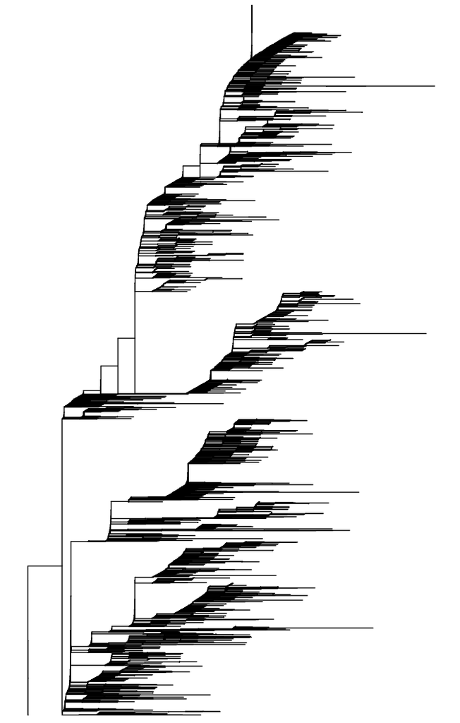

```r
mltr_addtips <- readRDS( system.file('mltr_addtips_mar2020.rds',
                                     package='treestructure') )
ggtree::ggtree(mltr_addtips)
```

And without the need to re-estimate a timetree or re-run `trestruct` from scratch, we are now able to add the new sequences to the existing `treestructure` object:

```r
trestruct_add_tips <- addtips(trst = trestruct_res, tre = mltr_addtips)
```

```
#> Some taxa in *trst* were not found in tre. These will be excluded from the output.
#>
```

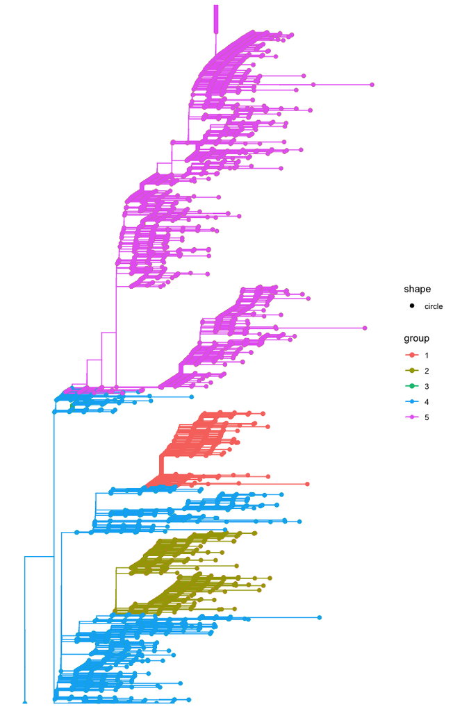

```r
plot(trestruct_add_tips, use_ggtree = T) + ggtree::geom_tippoint()
```